# Bakersfield Cactus Sampling Analysis: 2019

Malory Owen, Brooke Wainwright, Chris Lortie

1/31/2019

#### Let’s explore the abundance, size, and health of the federally and state endangered cactus, *Opuntia basilaris* var. *treleasei*, also known as the Bakersfield Cactus. A historical population exists at Wind Wolves Reserve, and after a particularly rainy season threatened to kill the historical population, other populations were establish with propagated paddles from the historical population.

## Data

#### Before we get into it, let’s just explore the data a bit.

```r
head(baca) #display it
```

```
## # A tibble: 6 x 18
##   OBJECTID Date  Inspector Protection Population Tag_number Year  Health
##      <int> <chr> <chr>     <chr>      <chr>           <int> <chr>  <int>
## 1      162 8/13~ Brooke W~ Rocks and~ Lobos             750 2014~      2
## 2      523 8/20~ Brooke W~ Rebar      Muddy             717 2014~      5
## 3        5 7/12~ Daisy Ca~ Rebar      San Emigd~        774 2014~      4
## 4       40 7/12~ Brooke W~ Rebar      San Emigd~        608 2013~      5
## 5       33 7/12~ Brooke W~ Rebar      San Emigd~        770 2014~      5
## 6       18 7/12~ Brooke W~ Rocks      San Emigd~        772 2014~      5
## # ... with 10 more variables: `Secondary Pads` <int>, `Tertiary
## #   Pads` <int>, `Quaternary Pads` <int>, Length <int>, Width <int>,
## #   Monitor <int>, Notes <chr>, GlobalID <chr>, x <dbl>, y <dbl>
```

```r
#How many cacti per site?
count(baca, Population)
```

```
## # A tibble: 6 x 2
##   Population      n
##   <chr>       <int>
## 1 Historic      161
## 2 Lobos         160
## 3 Muddy         101
## 4 Salt          114
## 5 San Emigdio   165
## 6 <NA>           91
```

```r
#Do we have different numbers of cacti measured each year?
count(baca, Year)
```

```
## # A tibble: 7 x 2
##   Year          n
##   <chr>     <int>
## 1 2012-2013   170
## 2 2013-2014    95
## 3 2014-2015   102
## 4 2015-2016   131
## 5 2016-2017   160
## 6 2017-2018   121
## 7 <NA>         13
```

```r
#How many cacti per protection type?
count(baca, Protection)
```

```
## # A tibble: 6 x 2
##   Protection          n
##   <chr>           <int>
## 1 None                5
## 2 Rebar             267
## 3 Rocks             411
## 4 Rocks and Rebar    54
## 5 Vaca               52
## 6 <NA>                3
```

## Location: Where are the cacti?

```r
#map all points
baca_map <- leaflet() %>%
  addTiles() %>%
  addCircleMarkers(lng = baca$x, lat = baca$y, radius = 5, color = "#DEAFD6")

baca_map #print
```

[interactive chart not shown]

[figure not shown]

```r
map.ww <- get_map(c(lon = -119.0862, lat = 35.01898), zoom = 11) #get basemap, must have google API
ggmap(map.ww) #plot basemap
```

[figure not shown]

```r
p <-ggmap(map.ww) +
  geom_point(data=baca, aes(x=x, y=y), alpha = .5, size = 1, color = "#FF78B3") +
  labs(x = "longitude", y = "latitude", color = "Plant")
p #plot points, format map, print
```

```r
#Map by Monitoring
pal4 <- colorFactor(c("#e4a6c1", "#c1e4a6", "#a6c1e4"), domain = c("0", "1", "2"))

leaflet(baca) %>% addTiles() %>%
  addCircleMarkers(
    lng = baca$x, lat= baca$y,
    color = ~pal4(Monitor),
    stroke = FALSE, fillOpacity = 0.5
  ) %>%
   addLegend("bottomright", pal = pal4, values = ~Monitor,
    title = "Cactus Census Monitoring Type",
    opacity = 1
  )
```

[interactive chart not shown]

```r
#Map the years
pal2 <- colorFactor(c("#366286", "#29266d", "#95b2d5", "#95d5c9", "#a2cd83", "#B272B6"), domain = c("2012-2013", "2013-2014", "2014-2015", "2015-2016", "2016-2017", "2017-2018"))

leaflet(baca) %>% addTiles() %>%
  addCircleMarkers(
    lng = baca$x, lat= baca$y,
    color = ~pal2(Year),
    stroke = FALSE, fillOpacity = 0.5
  ) %>%
   addLegend("bottomright", pal = pal2, values = ~Year,
    title = "Cactus Year",
    opacity = 1
  )
```

[interactive chart not shown]

```r
#Map the protecters

pal1 <- colorFactor(topo.colors(4), baca$Protection)

leaflet(baca) %>% addTiles() %>%
  addCircleMarkers(
    lng = baca$x, lat= baca$y,
    color = ~pal1(Protection),
    stroke = FALSE, fillOpacity = 0.5
  ) %>%
   addLegend("bottomright", pal = pal1, values = ~Protection,
    title = "Protection Type",
    opacity = 1
  )
```

[interactive chart not shown]

```r
#Map the health
pal3 <- colorFactor(c("black", "sienna", "indianred", "orange", "khaki", "#859469"), domain = c("0", "1", "2", "3", "4", "5"))

leaflet(baca) %>% addTiles() %>%
  addCircleMarkers(
    lng = baca$x, lat= baca$y,
    color = ~pal3(Health),
    stroke = FALSE, fillOpacity = 0.5
  ) %>%
   addLegend("bottomright", pal = pal3, values = ~Health,
    title = "Health of Cacti",
    opacity = 1
  )
```

[interactive chart not shown]

####Zoom in on maps for a closer look.

## Size of Cacti

#### We’ve seen the spatial distribution of our cacti by several different factors, but now let’s take a look at how they measure up. Additionally, size may be a measurement for reproductive success, especially as *Opuntia* strongly employ asexual propagation as a means of reproduction. For pollinators, there is evidence that height of an inflorescence impacts pollinator visition, and the same may be true for avian frugivores. For this data, we do not have a height measurement, but we do have Length and Width which may provide us with an approximate area. Understanding how size varies across the population may illuminate some truths about bird-cactus double mutualism.

```r
#a bit of wrangling
nabaca <- mutate(baca, Area.cm2 = Length * Width) #get an area column as product of length and width columns

nabaca <- nabaca %>% drop_na(Area.cm2) #get rid of columns with "na" values for area

mean(nabaca$Area.cm2) #mean area for all
```

```
## [1] 1640.562
```

```r
tapply(nabaca$Area.cm2, nabaca$Population, mean) #mean area of each population
```

```
##    Historic       Lobos       Muddy        Salt San Emigdio
##    1159.746    1735.255    1432.119    1651.420    2282.273
```

```r
tapply(nabaca$Area.cm2, nabaca$Protection, mean) #mean area of each protection method
```

```
##            None           Rebar           Rocks Rocks and Rebar
##        2236.500        1872.988        1146.131        3045.478
##            Vaca
##        2482.348
```

```r
tapply(nabaca$Area.cm2, nabaca$Year, mean) #mean area over each year--are they growing?
```

```
## 2012-2013 2013-2014 2014-2015 2015-2016 2016-2017 2017-2018
##  876.2667 2889.0000 2858.2609 1534.3269  636.7959  975.2549
```

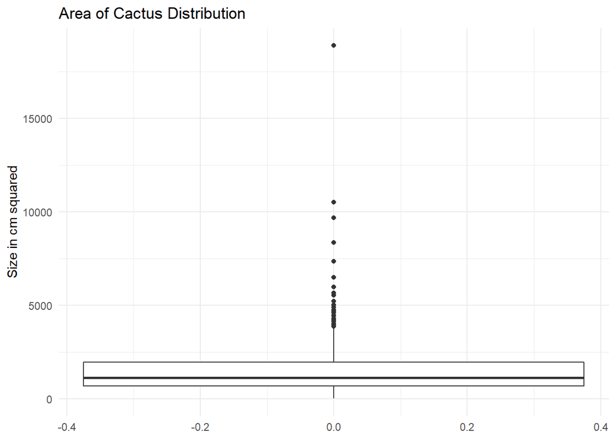

```r
ggplot(nabaca, aes(y=Area.cm2))+
  geom_boxplot() +labs(title = "Area of Cactus Distribution", y = "Size in cm squared") +
  theme_minimal() #looks like 23 outliers outside the 3rd quartile, but at least 1 extreme outlier that is likely an entry error, and perhaps 7 (?) that are entry errors.
```

```r
rosnerTest(nabaca$Area.cm2, k = 10) #number of statistical outliers detected is 9
```

```
##
## Results of Outlier Test
## -------------------------
##
## Test Method:                     Rosner's Test for Outliers
##
## Hypothesized Distribution:       Normal
##
## Data:                            nabaca$Area.cm2
##
## Sample Size:                     274
##
## Test Statistics:                 R.1  = 9.403731
##                                  R.2  = 5.926675
##                                  R.3  = 5.762237
##                                  R.4  = 5.167792
##                                  R.5  = 4.661235
##                                  R.6  = 4.160544
##                                  R.7  = 3.871753
##                                  R.8  = 3.716068
##                                  R.9  = 3.716129
##                                  R.10 = 3.520368
##
## Test Statistic Parameter:        k = 10
##
## Alternative Hypothesis:          Up to 10 observations are not
##                                  from the same Distribution.
##
## Type I Error:                    5%
##
## Number of Outliers Detected:     9
##
##    i   Mean.i     SD.i Value Obs.Num    R.i+1 lambda.i+1 Outlier
## 1  0 1640.562 1835.382 18900       1 9.403731   3.697780    TRUE
## 2  1 1577.341 1510.570 10530       2 5.926675   3.696733    TRUE
## 3  2 1544.426 1411.878  9680       3 5.762237   3.695682    TRUE
## 4  3 1514.406 1324.665  8360       4 5.167792   3.694627    TRUE
## 5  4 1489.052 1259.526  7360       5 4.661235   3.693567    TRUE
## 6  5 1467.227 1209.643  6500       6 4.160544   3.692502    TRUE
## 7  6 1448.448 1171.963  5986       7 3.871753   3.691433    TRUE
## 8  7 1431.453 1140.600  5670       8 3.716068   3.690360    TRUE
## 9  8 1415.519 1112.578  5550       9 3.716129   3.689282    TRUE
## 10 9 1399.917 1085.138  5220      10 3.520368   3.688199   FALSE
```

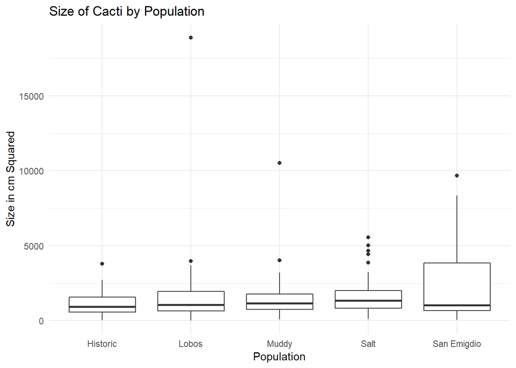

```r
ggplot(nabaca, aes(x = Population, y=Area.cm2)) +
  geom_boxplot() + labs(title = "Size of Cacti by Population", x = "Population", y = "Size in cm Squared") +
  theme_minimal()
```